# Binary Classifcation:

### Load Data:

```python
# load training data prepared previously

df_train = pd.read_csv('data/scld_final_train.csv')
df_train.head()
```

|  | id | cycle | setting1 | setting2 | setting3 | s1 | s2 | s3 | s4 | s5 | ... | s14 | s15 | s16 | s17 | s18 | s19 | s20 | s21 | RUL | cycle_norm |
| --- | --- | --- | --- | --- | --- | --- | --- | --- | --- | --- | --- | --- | --- | --- | --- | --- | --- | --- | --- | --- | --- |
| 0 | 1 | 1 | -0.315980 | -1.372953 | 0.0 | 0.0 | -1.721725 | -0.134255 | -0.925936 | -1.0 | ... | -0.269071 | -0.603816 | -1.0 | -0.781710 | 0.0 | 0.0 | 1.348493 | 1.194427 | 191 | -1.565170 |
| 1 | 1 | 2 | 0.872722 | -1.031720 | 0.0 | 0.0 | -1.061780 | 0.211528 | -0.643726 | -1.0 | ... | -0.642845 | -0.275852 | -1.0 | -0.781710 | 0.0 | 0.0 | 1.016528 | 1.236922 | 190 | -1.550652 |
| 2 | 1 | 3 | -1.961874 | 1.015677 | 0.0 | 0.0 | -0.661813 | -0.413166 | -0.525953 | -1.0 | ... | -0.551629 | -0.649144 | -1.0 | -2.073094 | 0.0 | 0.0 | 0.739891 | 0.503423 | 189 | -1.536134 |
| 3 | 1 | 4 | 0.324090 | -0.008022 | 0.0 | 0.0 | -0.661813 | -1.261314 | -0.784831 | -1.0 | ... | -0.520176 | -1.971665 | -1.0 | -0.781710 | 0.0 | 0.0 | 0.352598 | 0.777792 | 188 | -1.521616 |
| 4 | 1 | 5 | -0.864611 | -0.690488 | 0.0 | 0.0 | -0.621816 | -1.251528 | -0.301518 | -1.0 | ... | -0.521748 | -0.339845 | -1.0 | -0.136018 | 0.0 | 0.0 | 0.463253 | 1.059552 | 187 | -1.507098 |

5 rows × 28 columns

```python
# load test data prepared previously

df_test = pd.read_csv('data/scld_final_test.csv')
df_test.head()
```

|  | id | cycle | setting1 | setting2 | setting3 | s1 | s2 | s3 | s4 | s5 | ... | s14 | s15 | s16 | s17 | s18 | s19 | s20 | s21 | RUL | cycle_norm |
| --- | --- | --- | --- | --- | --- | --- | --- | --- | --- | --- | --- | --- | --- | --- | --- | --- | --- | --- | --- | --- | --- |
| 0 | 1 | 31 | -0.270260 | 1.356910 | 0.0 | 0.0 | -0.201850 | -1.517390 | -1.113706 | -1.0 | ... | -0.715188 | -1.059765 | -1.0 | -0.136018 | 0.0 | 0.0 | -0.034694 | 0.605041 | 112 | -1.129626 |
| 1 | 2 | 49 | 0.827003 | -0.349255 | 0.0 | 0.0 | -0.261846 | -0.641513 | 0.210682 | -1.0 | ... | -0.883465 | 0.222760 | -1.0 | -1.427402 | 0.0 | 0.0 | -0.034694 | -0.257790 | 98 | -0.868299 |
| 2 | 3 | 126 | -0.727453 | 1.356910 | 0.0 | 0.0 | 0.398100 | -0.126100 | 1.106199 | -1.0 | ... | -0.644417 | -0.806460 | -1.0 | 1.155367 | 0.0 | 0.0 | 0.629236 | -0.145087 | 69 | 0.249598 |
| 3 | 4 | 106 | 0.552687 | 1.356910 | 0.0 | 0.0 | 0.198117 | 0.653544 | -0.228188 | -1.0 | ... | -0.530136 | 0.566722 | -1.0 | 1.155367 | 0.0 | 0.0 | -1.307226 | -0.291971 | 82 | -0.040765 |
| 4 | 5 | 98 | -0.590295 | -1.372953 | 0.0 | 0.0 | -0.821799 | -0.095110 | 1.158419 | -1.0 | ... | -0.944275 | -0.158531 | -1.0 | 0.509675 | 0.0 | 0.0 | -0.366659 | 1.126989 | 91 | -0.156910 |

5 rows × 28 columns

```python
df_train.columns
```

```
Index(['id', 'cycle', 'setting1', 'setting2', 'setting3', 's1', 's2', 's3',
       's4', 's5', 's6', 's7', 's8', 's9', 's10', 's11', 's12', 's13', 's14',
       's15', 's16', 's17', 's18', 's19', 's20', 's21', 'RUL', 'cycle_norm'],
      dtype='object')
```

```python
w1 = 30
df_train['label1'] = np.where(df_train['RUL'] <= w1, 1, 0 )
df_train.head()
```

|  | id | cycle | setting1 | setting2 | setting3 | s1 | s2 | s3 | s4 | s5 | ... | s15 | s16 | s17 | s18 | s19 | s20 | s21 | RUL | cycle_norm | label1 |
| --- | --- | --- | --- | --- | --- | --- | --- | --- | --- | --- | --- | --- | --- | --- | --- | --- | --- | --- | --- | --- | --- |
| 0 | 1 | 1 | -0.315980 | -1.372953 | 0.0 | 0.0 | -1.721725 | -0.134255 | -0.925936 | -1.0 | ... | -0.603816 | -1.0 | -0.781710 | 0.0 | 0.0 | 1.348493 | 1.194427 | 191 | -1.565170 | 0 |
| 1 | 1 | 2 | 0.872722 | -1.031720 | 0.0 | 0.0 | -1.061780 | 0.211528 | -0.643726 | -1.0 | ... | -0.275852 | -1.0 | -0.781710 | 0.0 | 0.0 | 1.016528 | 1.236922 | 190 | -1.550652 | 0 |
| 2 | 1 | 3 | -1.961874 | 1.015677 | 0.0 | 0.0 | -0.661813 | -0.413166 | -0.525953 | -1.0 | ... | -0.649144 | -1.0 | -2.073094 | 0.0 | 0.0 | 0.739891 | 0.503423 | 189 | -1.536134 | 0 |
| 3 | 1 | 4 | 0.324090 | -0.008022 | 0.0 | 0.0 | -0.661813 | -1.261314 | -0.784831 | -1.0 | ... | -1.971665 | -1.0 | -0.781710 | 0.0 | 0.0 | 0.352598 | 0.777792 | 188 | -1.521616 | 0 |
| 4 | 1 | 5 | -0.864611 | -0.690488 | 0.0 | 0.0 | -0.621816 | -1.251528 | -0.301518 | -1.0 | ... | -0.339845 | -1.0 | -0.136018 | 0.0 | 0.0 | 0.463253 | 1.059552 | 187 | -1.507098 | 0 |

5 rows × 29 columns

```python
df_test['label1'] = np.where(df_test['RUL'] <= w1, 1, 0 )
df_test.head()
```

|  | id | cycle | setting1 | setting2 | setting3 | s1 | s2 | s3 | s4 | s5 | ... | s15 | s16 | s17 | s18 | s19 | s20 | s21 | RUL | cycle_norm | label1 |
| --- | --- | --- | --- | --- | --- | --- | --- | --- | --- | --- | --- | --- | --- | --- | --- | --- | --- | --- | --- | --- | --- |
| 0 | 1 | 31 | -0.270260 | 1.356910 | 0.0 | 0.0 | -0.201850 | -1.517390 | -1.113706 | -1.0 | ... | -1.059765 | -1.0 | -0.136018 | 0.0 | 0.0 | -0.034694 | 0.605041 | 112 | -1.129626 | 0 |
| 1 | 2 | 49 | 0.827003 | -0.349255 | 0.0 | 0.0 | -0.261846 | -0.641513 | 0.210682 | -1.0 | ... | 0.222760 | -1.0 | -1.427402 | 0.0 | 0.0 | -0.034694 | -0.257790 | 98 | -0.868299 | 0 |
| 2 | 3 | 126 | -0.727453 | 1.356910 | 0.0 | 0.0 | 0.398100 | -0.126100 | 1.106199 | -1.0 | ... | -0.806460 | -1.0 | 1.155367 | 0.0 | 0.0 | 0.629236 | -0.145087 | 69 | 0.249598 | 0 |
| 3 | 4 | 106 | 0.552687 | 1.356910 | 0.0 | 0.0 | 0.198117 | 0.653544 | -0.228188 | -1.0 | ... | 0.566722 | -1.0 | 1.155367 | 0.0 | 0.0 | -1.307226 | -0.291971 | 82 | -0.040765 | 0 |
| 4 | 5 | 98 | -0.590295 | -1.372953 | 0.0 | 0.0 | -0.821799 | -0.095110 | 1.158419 | -1.0 | ... | -0.158531 | -1.0 | 0.509675 | 0.0 | 0.0 | -0.366659 | 1.126989 | 91 | -0.156910 | 0 |

5 rows × 29 columns

```python
# Selecting the features by removing the constant sensor values as well as settings
features = ['cycle_norm','s2', 's3',
       's4', 's7', 's8', 's9', 's11', 's12', 's13', 's14',
       's15', 's17','s20', 's21']
```

```python
feature1 = ['cycle_norm','s4', 's7', 's9', 's11']
```

```python
# Creating the train & test sets based on the seleceted features
X_train = df_train[features]
X_test = df_test[features]
```

```python
y_train = df_train['label1']
y_test = df_test['label1']
print(X_train.shape)
print(y_train.shape)
print(X_test.shape)
print(y_test.shape)
```

```
(20631, 15)
(20631,)
(100, 15)
(100,)
```

```python
y_train.value_counts()
```

```
0    17531
1     3100
Name: label1, dtype: int64
```

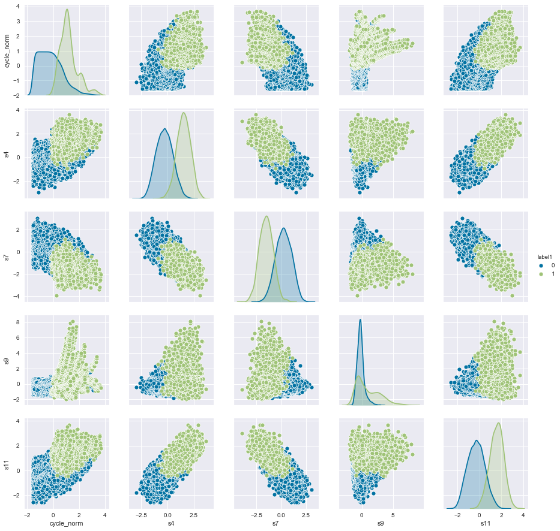

```python
g = sns.pairplot(data=df_train, vars=feature1, hue='label1')
plt.savefig('pairplot')
```

```python
def plot_sensor_histogram(sensor ,xlimit,sensor_name,plotname):
    fig, ax1 = plt.subplots(1, 1, figsize=(16,4))
    """ Create sensor_healthy_subset to hold the first few rows of the sensor values
         when the engine cycle starts from 1
         According to a research paper this is where the sensor values actor normal
         we will label it as healthy state
    """
    sensor_healthy_subset = df_train.groupby('id').head(30)[sensor]

    """ Create sensor_failing_subset to hold the last few rows of the sensor values
         when the engine cycle is reaching its degradation/failure state
         According to a research paper this is where the sensor values actor abnormal
         we will label it as failing state

    """
    sensor_failing_subset = df_train.groupby('id').tail(30)[sensor]

    # Now we shall plot the histogram of the healthy and failing state of the sensors across all engine's cycles
    sensor_healthy_subset.plot(kind='hist', bins=15, label='Healthy', xlim = xlimit ,color='green', alpha=0.5, ax=ax1)
    sensor_failing_subset.plot(kind='hist', bins=15, label='Failing',xlim = xlimit, color='red', alpha=0.5, ax=ax1)
    ax1.set_title('sensor'+" "+sensor+' -- '+" "+ sensor_name, fontsize=18)
    plt.tight_layout()
    plt.show()
    fig.savefig("images/"+plotname,transparent=False, dpi=100, bbox_inches="tight")
```

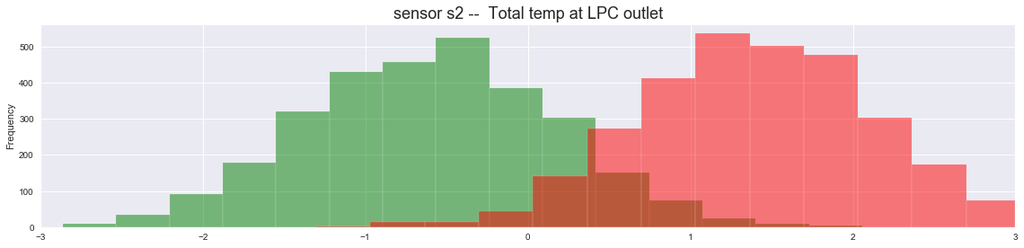

```python
s2_hist_plot = plot_sensor_histogram('s2' ,(-3,3),'Total temp at LPC outlet','sensors2_histplot.png')
```

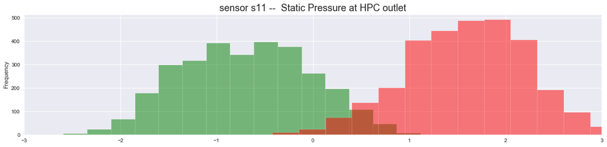

```python
s11_hist_plot = plot_sensor_histogram('s11' ,(-3,3),'Static Pressure at HPC outlet','sensors11_histplot.png')
```

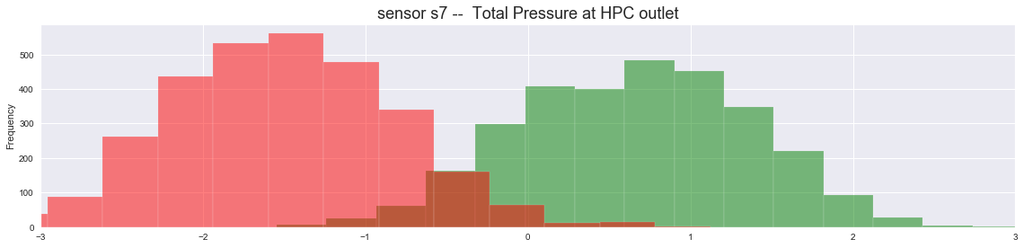

```python
s7_hist_plot = plot_sensor_histogram('s7' ,(-3,3),'Total Pressure at HPC outlet','sensors7_histplot.png')
```

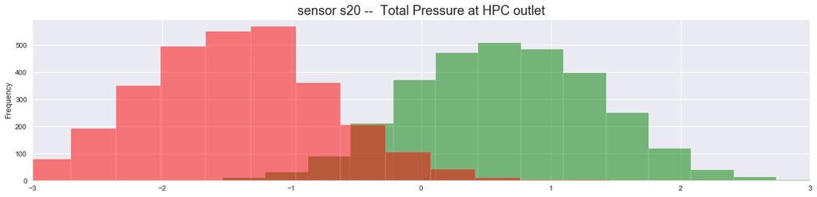

```python
s7_hist_plot = plot_sensor_histogram('s20' ,(-3,3),'Total Pressure at HPC outlet','sensors7_histplot.png')
```

# Evaluation of classifier metrics

### Accuracy

Accuracy is calculated as the number of all correct predictions divided by the total number of the dataset. The best accuracy is 1.0, whereas the worst is 0.0

### Sensitivity or Recall or True Positive Rate

Recall is calculated as the number of correct positive predictions divided by the total number of positives. It is also called recall (REC) or true positive rate (TPR). The best sensitivity is 1.0, whereas the worst is 0.0.

### Specificity or True Negative Rate

Specificity (SP) is calculated as the number of correct negative predictions divided by the total number of negatives. It is also called true negative rate (TNR). The best specificity is 1.0, whereas the worst is 0.0.

### Precision (Positive predictive value)

Precision (PREC) is calculated as the number of correct positive predictions divided by the total number of positive predictions. It is also called positive predictive value (PPV). The best precision is 1.0, whereas the worst is 0.0.

### False positive rate

False positive rate (FPR) is calculated as the number of incorrect positive predictions divided by the total number of negatives. The best false positive rate is 0.0 whereas the worst is 1.0. It can also be calculated as 1 – specificity.

### Matthews correlation coefficient

The Matthews correlation coefficient is used in machine learning as a measure of the quality of binary (two-class) classifications. It takes into account true and false positives and negatives and is generally regarded as a balanced measure which can be used even if the classes are of very different sizes

### F1- Score

The F1 score can be interpreted as a weighted average of the precision and recall, where an F1 score reaches its best value at 1 and worst score at 0.

### ROC AUC

Compute Area Under the Receiver Operating Characteristic Curve (ROC AUC) from prediction scores.It allows for interpretation of how much area under the curve a model covers with respect to all the class lables in classification (binary or multiclass).values near to 1.0 is higher and values closer 0 are understood to be poor classification

#### Let us add some helper fuctions

```python
def classifier_metrics(model,estimator,actual,y_pred,y_score):
    # Calculating the classification metrics -
    # Input - model predicted values and probablilites
    class_metrics ={
                        'Accuracy' : metrics.accuracy_score(actual, y_pred),
                        'Precision' : metrics.precision_score(actual, y_pred),
                        'Recall' : metrics.recall_score(actual, y_pred),
                        'F1 Score' : metrics.f1_score(actual, y_pred),
                        'ROC AUC' : metrics.roc_auc_score(actual, y_score),
                        'Matthews Correlation Coefficient': matthews_corrcoef(actual,y_pred)
                      }


    df_metrics = pd.DataFrame.from_dict(class_metrics, orient='index')
    df_metrics.columns = [model]

    print('\n'+ model +'  Metrics:')

    print(df_metrics)
    # Calculating and displaying confusion matrix for each model
    print('\nConfusion Matrix:')
    skplt.metrics.plot_confusion_matrix(actual, y_pred)
    return  df_metrics
```

```python
def plot_roc(model,title):
    # input - model estimator and title to save plot

    # Calculate the probabilites of predicted values - probability of belong to a class 0 or 1
    model_proba = model.predict_proba(X_test)

    fig = plt.figure()

    ax1 = fig.add_subplot()

    skplt.metrics.plot_roc(y_test,model_proba ,figsize = (15,7),title_fontsize='large',text_fontsize='large')

    plt.savefig('images/binaryclassification/'+title, transparent=False, dpi=80, bbox_inches="tight")

    return None
```

```python
def plot_learning_curve(estimator, title, X, y, ylim=None, cv=None, scoring=None, obj_line=None,
                        n_jobs=1, train_sizes=np.linspace(.1, 1.0, 5)):
    """
    Generate a simple plot of the test and training learning curve.

    Parameters
    ----------
    estimator : object type that implements the "fit" and "predict" methods
        An object of that type which is cloned for each validation.

    title : string
        Title for the chart.

    X : array-like, shape (n_samples, n_features)
        Training vector, where n_samples is the number of samples and
        n_features is the number of features.

    y : array-like, shape (n_samples) or (n_samples, n_features), optional
        Target relative to X for classification or regression;
        None for unsupervised learning.

    ylim : tuple, shape (ymin, ymax), optional
        Defines minimum and maximum yvalues plotted.

    cv : int, cross-validation generator or an iterable, optional
        Determines the cross-validation splitting strategy.
        Possible inputs for cv are:
          - None, to use the default 3-fold cross-validation,
          - integer, to specify the number of folds.
          - An object to be used as a cross-validation generator.
          - An iterable yielding train/test splits.

        For integer/None inputs, if ``y`` is binary or multiclass,
        :class:`StratifiedKFold` used. If the estimator is not a classifier
        or if ``y`` is neither binary nor multiclass, :class:`KFold` is used.

        Refer :ref:`User Guide <cross_validation>` for the various
        cross-validators that can be used here.

    scoring : string, callable or None, optional, default: None
              A string (see model evaluation documentation)
              or a scorer callable object / function with signature scorer(estimator, X, y)
              For Python 3.5 the documentation is here:
              http://scikit-learn.org/stable/modules/model_evaluation.html#scoring-parameter
              For example, Log Loss is specified as 'neg_log_loss'

    obj_line : numeric or None (default: None)
               draw a horizontal line


    n_jobs : integer, optional
        Number of jobs to run in parallel (default 1).


    Citation
    --------
        http://scikit-learn.org/stable/auto_examples/model_selection/plot_learning_curve.html

    Usage
    -----
        plot_learning_curve(estimator = best_estimator,
                            title     = best_estimator_title,
                            X         = X_train,
                            y         = y_train,
                            ylim      = (-1.1, 0.1), # neg_log_loss is negative
                            cv        = StatifiedCV, # CV generator
                            scoring   = scoring,     # eg., 'neg_log_loss'
                            obj_line  = obj_line,    # horizontal line
                            n_jobs    = n_jobs)      # how many CPUs

         plt.show()
    """
    from sklearn.model_selection import learning_curve
    import numpy as np
    from matplotlib import pyplot as plt

    plt.figure()
    plt.title(title)
    if ylim is not None:
        plt.ylim(*ylim)
    plt.xlabel("Training examples")
    plt.ylabel("Score")
    train_sizes, train_scores, test_scores = learning_curve(
        estimator, X, y, cv=cv, scoring=scoring, n_jobs=n_jobs, train_sizes=train_sizes)
    train_scores_mean = np.mean(train_scores, axis=1)
    train_scores_std  = np.std(train_scores, axis=1)
    test_scores_mean  = np.mean(test_scores, axis=1)
    test_scores_std   = np.std(test_scores, axis=1)
    plt.grid(True)

    plt.fill_between(train_sizes, train_scores_mean - train_scores_std,
                     train_scores_mean + train_scores_std, alpha=0.1,
                     color="r")
    plt.fill_between(train_sizes, test_scores_mean - test_scores_std,
                     test_scores_mean + test_scores_std, alpha=0.1, color="g")
    plt.plot(train_sizes, train_scores_mean, 'o-', color="r",
             label="Training score")
    plt.plot(train_sizes, test_scores_mean, 'o-', color="g",
             label="Cross-validation score")

    if obj_line:
        plt.axhline(y=obj_line, color='blue')

    plt.legend(loc="best")
    return plt
```

```python
def threshold_adjust(model,title,fbeta):
    #input - model estimator and title to save plot
    fig = plt.figure(figsize = (8,6))
    ax1 = fig.add_subplot(1,1,1)
    ax1.set_title('Threshold Plot for'+title,fontsize=20)
    ax1.set_xlabel('Discrimation Threshold',fontsize=16)
    ax1.set_ylabel('Score',fontsize=16)# Evaluate the model on the test data
    ax1.tick_params(labelsize=12)
    ax1.legend(loc ='lower left', fontsize='large')
    cv = StratifiedKFold(5)
    visualizer = DiscriminationThreshold(model,cv=cv,argmax='fscore',
                                     fbeta=fbeta,random_state=42,ax=ax1,n_trials = 5)

    visualizer.fit(X_train, y_train)  # Fit the training data to the visualizer
    visualizer.finalize()

    fig.savefig('images/binaryclassification/'+title, transparent=False, dpi=80)

    return None
```

```python
def precision_recall(model,title):
    #input - model estimator and title to save plot

    # Calculate model -  predicted value probabilites - that it belongs to 0 or 1
    model_proba = model.predict_proba(X_test)

    fig = plt.figure()
    ax1 = fig.add_subplot()

    skplt.metrics.plot_precision_recall(y_test,model_proba,figsize = (15,7),title_fontsize='large',text_fontsize='large')

    plt.savefig('images/binaryclassification/'+title, transparent=False, dpi=80, bbox_inches="tight")

    return None
```

```python
def precision_recall_metrics(model,y_test,y_pred,y_score,title):

    # input - model estimator, predicted values, predict probabilites or decision values & title

    # PRecision recall curve metric - output gives model tradeoff between precision & recall

    # thresholds - decision threshold - classfiy data with respect to precision/recall

    precision, recall, thresholds = metrics.precision_recall_curve(y_test, y_score)

    thresholds = np.append(thresholds,1)
    #queue -queue rate determines the % of number of engines that represent class 1 - need maintenance
    queue_rate = []
    for threshold in thresholds:
        queue_rate.append((y_score >= threshold).mean())

    queue_rate = np.array(queue_rate)

    precision_recall = {
                    'Threshold' : thresholds,
                    'Precision' : precision,
                    'Recall' : recall,
                    'Que' : queue_rate
                 }

    df_precision_recall = pd.DataFrame.from_dict(precision_recall)
    df_precision_recall['model'] =model

    fig, ((ax1, ax2)) =  plt.subplots(nrows=1, ncols=2)
    fig.set_size_inches(18,10)
    ax1.plot(recall, precision, color='navy', lw=2, label='Precision-Recall curve')
    ax1.set_xlim([0.0, 1.0])
    ax1.set_ylim([0.0, 1.05])
    ax1.tick_params(labelsize=16)
    ax1.set_xlabel('Recall',fontsize=20)
    ax1.set_ylabel('Precision',fontsize=20)
    ax1.legend(loc="lower left", fontsize='large')

    ax2.plot(thresholds, precision, color='red', lw=2, label='Precision')
    ax2.plot(thresholds, recall, color='green',label='Recall')
    ax2.plot(thresholds, queue_rate, color='blue',label='Engines')
    ax2.set_ylim([0.0, 1.05])
    ax2.tick_params(labelsize=16)
    ax2.set_xlabel('Threshold',fontsize=20)
    ax2.set_ylabel('%',fontsize=20)
    ax2.legend(loc='lower left', fontsize='large')
    plt.savefig('images/binaryclassification/'+title, transparent=False, dpi=80, bbox_inches="tight")
    return df_precision_recall
```

```python
import os
import pickle
import shap
shap.initjs()
```